# Análisis de Reservas Hoteleras

Victor, Rene, Noe, Jhon, Julio

2025-10-03

# Integrantes

- Maye Mamani Victor Raul
- Machaca Chambilla Noe Ulises
- Gonzales Quispe Jhon Cristhian
- Ccoyto Pachapuma Rene Rolando
- Eduardo Maquera Julio Segundo

# Contexto

## CONTEXTO DEL PROBLEMA

Las cancelaciones de reservas representan una **pérdida significativa de ingresos** para la industria hotelera. En un entorno donde las reservas online permiten cancelaciones gratuitas o de bajo costo, entender los patrones detrás de estas decisiones se convierte en **crucial para la rentabilidad del negocio**.

## OBJETIVOS PRINCIPALES

1. **Identificar** los factores clave que influyen en las cancelaciones
2. **Cuantificar** el impacto económico potencial de las cancelaciones
3. **Proporcionar** insights accionables para reducir tasas de cancelación
4. **Segmentar** clientes según su propensión a cancelar

## PREGUNTAS DE INVESTIGACIÓN

### • ¿Qué características de las reservas predicen mayor probabilidad de cancelación?

**Análisis de variables predictoras y su impacto en el comportamiento de cancelación**

### • ¿Existen patrones temporales en las cancelaciones?

**Identificación de estacionalidad y tendencias en el tiempo**

### • ¿Cómo influye el precio y la anticipación en la decisión de cancelar?

**Análisis de sensibilidad al precio y efecto del lead time**

### • ¿Los clientes recurrentes muestran diferente comportamiento?

**Comparación de patrones entre clientes nuevos y recurrentes**

# Cargar librerías necesarias

```r
library(readxl)
library(dplyr)
library(ggplot2)
library(corrplot)
library(reshape2)
library(lubridate)
```

# Cargar datos

```r
# Cargar los datos
datos <- read.table("C:\\Users\\USER\\OneDrive\\Documentos\\unap\\9no\\cienciadatos2\\data_hoteles.txt", header = TRUE, sep = ",")

# Exploración inicial
cat("Dimensiones del dataset:", dim(datos), "\n")
```

```
## Dimensiones del dataset: 36275 19
```

```r
cat("Estructura del dataset:\n")
```

```
## Estructura del dataset:
```

```r
str(datos)
```

```
## 'data.frame':    36275 obs. of  19 variables:
##  $ Booking_ID                          : chr  "INN00001" "INN00002" "INN00003" "INN00004" ...
##  $ no_of_adults                        : int  2 2 1 2 2 2 2 2 3 2 ...
##  $ no_of_children                      : int  0 0 0 0 0 0 0 0 0 0 ...
##  $ no_of_weekend_nights                : int  1 2 2 0 1 0 1 1 0 0 ...
##  $ no_of_week_nights                   : int  2 3 1 2 1 2 3 3 4 5 ...
##  $ type_of_meal_plan                   : chr  "Meal Plan 1" "Not Selected" "Meal Plan 1" "Meal Plan 1" ...
##  $ required_car_parking_space          : int  0 0 0 0 0 0 0 0 0 0 ...
##  $ room_type_reserved                  : chr  "Room_Type 1" "Room_Type 1" "Room_Type 1" "Room_Type 1" ...
##  $ lead_time                           : int  224 5 1 211 48 346 34 83 121 44 ...
##  $ arrival_year                        : int  2017 2018 2018 2018 2018 2018 2017 2018 2018 2018 ...
##  $ arrival_month                       : int  10 11 2 5 4 9 10 12 7 10 ...
##  $ arrival_date                        : int  2 6 28 20 11 13 15 26 6 18 ...
##  $ market_segment_type                 : chr  "Offline" "Online" "Online" "Online" ...
##  $ repeated_guest                      : int  0 0 0 0 0 0 0 0 0 0 ...
##  $ no_of_previous_cancellations        : int  0 0 0 0 0 0 0 0 0 0 ...
##  $ no_of_previous_bookings_not_canceled: int  0 0 0 0 0 0 0 0 0 0 ...
##  $ avg_price_per_room                  : num  65 106.7 60 100 94.5 ...
##  $ no_of_special_requests              : int  0 1 0 0 0 1 1 1 1 3 ...
##  $ booking_status                      : chr  "Not_Canceled" "Not_Canceled" "Canceled" "Canceled" ...
```

```r
cat("Primeras filas del dataset:\n")
```

```
## Primeras filas del dataset:
```

```r
head
```

```
## function (x, ...)
## UseMethod("head")
## <bytecode: 0x000001daaa772300>
## <environment: namespace:utils>
```

```r
cat("
METODOLOGÍA:
Dataset analizado contiene", nrow(datos), "reservas con", ncol(datos), "variables
por reserva. El análisis combina estadística descriptiva, visualización de datos
y análisis de correlaciones para identificar patrones significativos.
")
```

```
##
## METODOLOGÍA:
## Dataset analizado contiene 36275 reservas con 19 variables
## por reserva. El análisis combina estadística descriptiva, visualización de datos
## y análisis de correlaciones para identificar patrones significativos.
```

# Limpieza de datos

```r
# Verificar valores nulos
cat("Valores nulos por variable:\n")
```

```
## Valores nulos por variable:
```

```r
sapply(datos, function(x) sum(is.na(x)))
```

```
##                           Booking_ID                         no_of_adults
##                                    0                                    0
##                       no_of_children                 no_of_weekend_nights
##                                    0                                    0
##                    no_of_week_nights                    type_of_meal_plan
##                                    0                                    0
##           required_car_parking_space                   room_type_reserved
##                                    0                                    0
##                            lead_time                         arrival_year
##                                    0                                    0
##                        arrival_month                         arrival_date
##                                    0                                    0
##                  market_segment_type                       repeated_guest
##                                    0                                    0
##         no_of_previous_cancellations no_of_previous_bookings_not_canceled
##                                    0                                    0
##                   avg_price_per_room               no_of_special_requests
##                                    0                                    0
##                       booking_status
##                                    0
```

```r
# Verificar duplicados
cat("Número de filas duplicadas:", sum(duplicated(datos)), "\n")
```

```
## Número de filas duplicadas: 0
```

```r
# Convertir variables categóricas a factores
datos$booking_status <- as.factor(datos$booking_status)
datos$type_of_meal_plan <- as.factor(datos$type_of_meal_plan)
datos$room_type_reserved <- as.factor(datos$room_type_reserved)
datos$market_segment_type <- as.factor(datos$market_segment_type)
```

# Analisis descriptivo

## Resumen descriptivo (univariante)

```r
# Resumen estadístico
num_vars <- sapply(datos, is.numeric)
summary(datos[, num_vars])
```

```
##   no_of_adults   no_of_children    no_of_weekend_nights no_of_week_nights
##  Min.   :0.000   Min.   : 0.0000   Min.   :0.0000       Min.   : 0.000
##  1st Qu.:2.000   1st Qu.: 0.0000   1st Qu.:0.0000       1st Qu.: 1.000
##  Median :2.000   Median : 0.0000   Median :1.0000       Median : 2.000
##  Mean   :1.845   Mean   : 0.1053   Mean   :0.8107       Mean   : 2.204
##  3rd Qu.:2.000   3rd Qu.: 0.0000   3rd Qu.:2.0000       3rd Qu.: 3.000
##  Max.   :4.000   Max.   :10.0000   Max.   :7.0000       Max.   :17.000
##  required_car_parking_space   lead_time       arrival_year  arrival_month
##  Min.   :0.00000            Min.   :  0.00   Min.   :2017   Min.   : 1.000
##  1st Qu.:0.00000            1st Qu.: 17.00   1st Qu.:2018   1st Qu.: 5.000
##  Median :0.00000            Median : 57.00   Median :2018   Median : 8.000
##  Mean   :0.03099            Mean   : 85.23   Mean   :2018   Mean   : 7.424
##  3rd Qu.:0.00000            3rd Qu.:126.00   3rd Qu.:2018   3rd Qu.:10.000
##  Max.   :1.00000            Max.   :443.00   Max.   :2018   Max.   :12.000
##   arrival_date  repeated_guest    no_of_previous_cancellations
##  Min.   : 1.0   Min.   :0.00000   Min.   : 0.00000
##  1st Qu.: 8.0   1st Qu.:0.00000   1st Qu.: 0.00000
##  Median :16.0   Median :0.00000   Median : 0.00000
##  Mean   :15.6   Mean   :0.02564   Mean   : 0.02335
##  3rd Qu.:23.0   3rd Qu.:0.00000   3rd Qu.: 0.00000
##  Max.   :31.0   Max.   :1.00000   Max.   :13.00000
##  no_of_previous_bookings_not_canceled avg_price_per_room no_of_special_requests
##  Min.   : 0.0000                      Min.   :  0.00     Min.   :0.0000
##  1st Qu.: 0.0000                      1st Qu.: 80.30     1st Qu.:0.0000
##  Median : 0.0000                      Median : 99.45     Median :0.0000
##  Mean   : 0.1534                      Mean   :103.42     Mean   :0.6197
##  3rd Qu.: 0.0000                      3rd Qu.:120.00     3rd Qu.:1.0000
##  Max.   :58.0000                      Max.   :540.00     Max.   :5.0000
```

```r
# Variables categóricas básicas: contar niveles
cat_vars <- names(datos)[sapply(datos, function(x) is.character(x) || is.factor(x))]
lapply(datos[cat_vars], function(x) {
  tmp <- table(x, useNA="ifany")
  head(tmp, 10)
})
```

```
## $Booking_ID
## x
## INN00001 INN00002 INN00003 INN00004 INN00005 INN00006 INN00007 INN00008
##        1        1        1        1        1        1        1        1
## INN00009 INN00010
##        1        1
##
## $type_of_meal_plan
## x
##  Meal Plan 1  Meal Plan 2  Meal Plan 3 Not Selected
##        27835         3305            5         5130
##
## $room_type_reserved
## x
## Room_Type 1 Room_Type 2 Room_Type 3 Room_Type 4 Room_Type 5 Room_Type 6
##       28130         692           7        6057         265         966
## Room_Type 7
##         158
##
## $market_segment_type
## x
##      Aviation Complementary     Corporate       Offline        Online
##           125           391          2017         10528         23214
##
## $booking_status
## x
##     Canceled Not_Canceled
##        11885        24390
```

# Análisis exploratorio

## Análisis de la variable objetivo: booking_status

```r
cat("Distribución de booking_status:\n")
```

```
## Distribución de booking_status:
```

```r
table(datos$booking_status)
```

```
##
##     Canceled Not_Canceled
##        11885        24390
```

```r
prop.table(table(datos$booking_status)) * 100
```

```
##
##     Canceled Not_Canceled
##     32.76361     67.23639
```

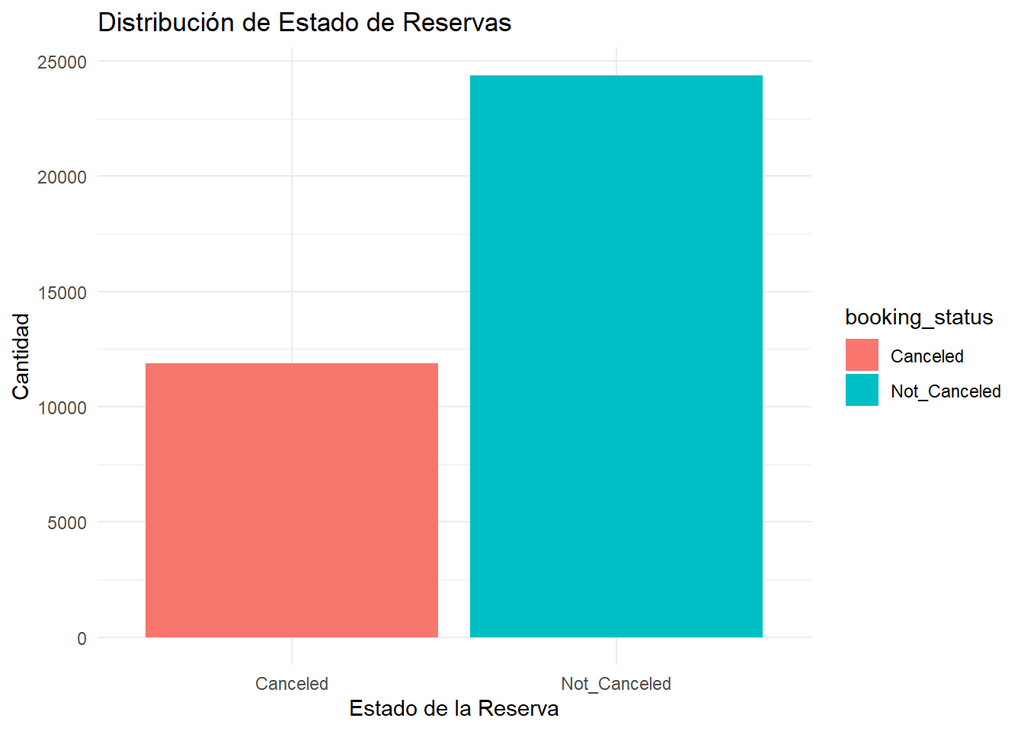

```r
# Visualización de la variable objetivo
ggplot(datos, aes(x = booking_status, fill = booking_status)) +
  geom_bar() +
  labs(title = "Distribución de Estado de Reservas",
       x = "Estado de la Reserva",
       y = "Cantidad") +
  theme_minimal()
```

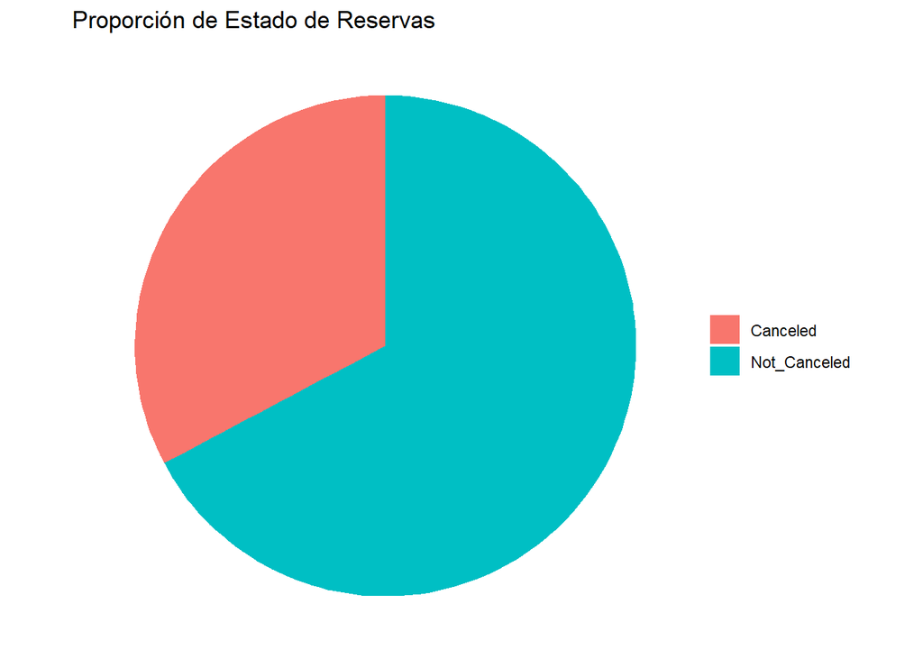

```r
# grafico circular

ggplot(datos, aes(x = "", fill = booking_status)) +
  geom_bar(width = 1) +
  coord_polar("y", start = 0) +
  labs(title = "Proporción de Estado de Reservas") +
  theme_void() +
  theme(legend.title = element_blank())
```

## Análisis de variables numéricas clave

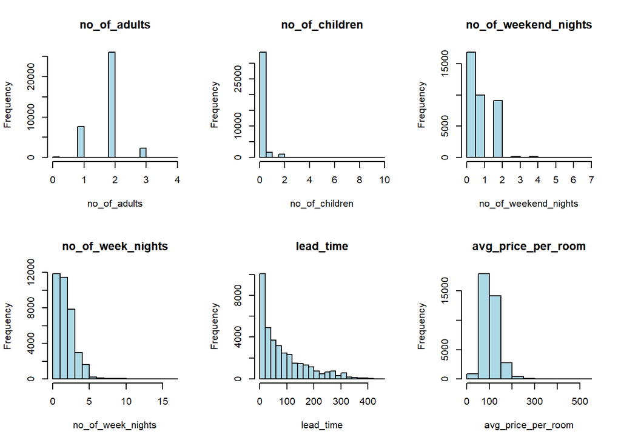

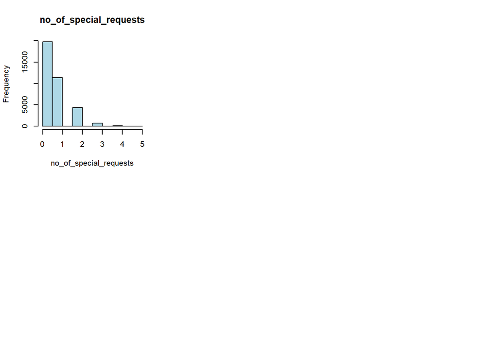

```r
variables_numericas <- datos %>%
  select(no_of_adults, no_of_children, no_of_weekend_nights,
         no_of_week_nights, lead_time, avg_price_per_room,
         no_of_special_requests)

# Histogramas de variables numéricas
par(mfrow = c(2, 3))
for (i in 1:ncol(variables_numericas)) {
  hist(variables_numericas[[i]], main = names(variables_numericas)[i],
       xlab = names(variables_numericas)[i], col = "lightblue")
}
```

**INTERPRETACION**

- **Lead Time**: Promedio de 85 días con amplia variabilidad (0-443 días)
- **Precio promedio**: 103.42€ con rango amplio (0-540€), sugiriendo estrategias de precios dinámicos
- **Huéspedes recurrentes**: Solo 2.56% de la base, oportunidad para programas de fidelización
- **Solicitudes especiales**: Promedio bajo (0.62), indicando potencial para personalización

## Análisis de cancelaciones por diferentes factores

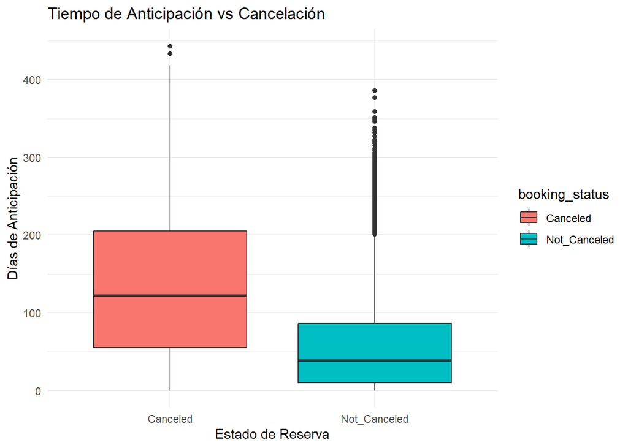

```r
# 1. Cancelaciones por lead_time
ggplot(datos, aes(x = booking_status, y = lead_time, fill = booking_status)) +
  geom_boxplot() +
  labs(title = "Tiempo de Anticipación vs Cancelación",
       x = "Estado de Reserva", y = "Días de Anticipación") +
  theme_minimal()
```

## Cancelaciones por tipo de habitación y plan de comidas

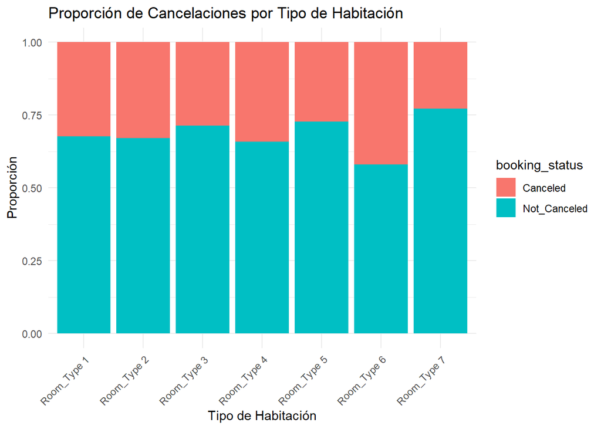

```r
ggplot(datos, aes(x = room_type_reserved, fill = booking_status)) +
  geom_bar(position = "fill") +
  labs(title = "Proporción de Cancelaciones por Tipo de Habitación",
       x = "Tipo de Habitación", y = "Proporción") +
  theme_minimal() +
  theme(axis.text.x = element_text(angle = 45, hjust = 1))
```

## Cancelaciones por plan de comidas

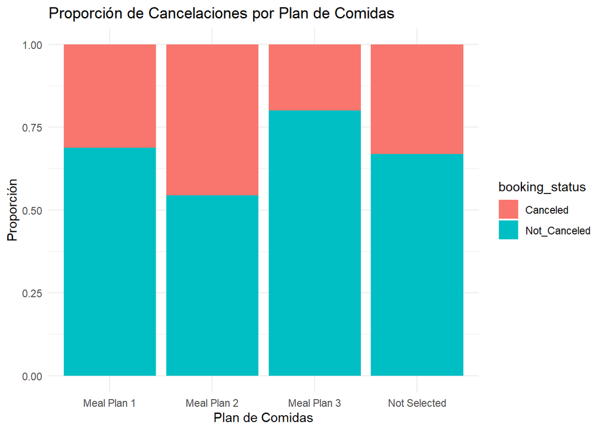

```r
ggplot(datos, aes(x = type_of_meal_plan, fill = booking_status)) +
  geom_bar(position = "fill") +
  labs(title = "Proporción de Cancelaciones por Plan de Comidas",
       x = "Plan de Comidas", y = "Proporción") +
  theme_minimal()
```

## Analisis temporal

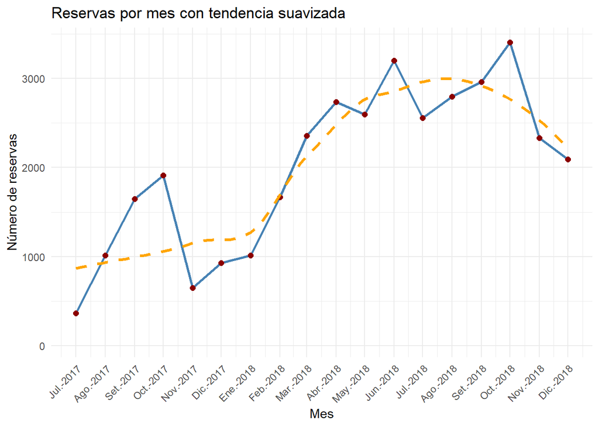

```r
# Crear columna de fecha y agrupar por mes
df_monthly <- datos %>%
  mutate(arrival_date_full = make_date(arrival_year, arrival_month, arrival_date),
         month = floor_date(arrival_date_full, "month")) %>%
  group_by(month) %>%
  summarise(total_bookings = n())

# Gráfico por meses con línea suavizada
ggplot(df_monthly, aes(x = month, y = total_bookings)) +
  geom_line(color = "steelblue", size = 1) +
  geom_point(color = "darkred", size = 2) +
  geom_smooth(method = "loess", se = FALSE,
              color = "orange", size = 1.2, linetype = "dashed") +
  scale_x_date(date_breaks = "1 month", date_labels = "%b-%Y") +  # todos los meses
  labs(title = "Reservas por mes con tendencia suavizada",
       x = "Mes", y = "Número de reservas") +
  theme_minimal() +
  theme(axis.text.x = element_text(angle = 45, hjust = 1))
```

## Análisis de la situación actual de la var objetivo

```r
cat("DISTRIBUCIÓN EXACTA DE booking_status:\n")
```

```
## DISTRIBUCIÓN EXACTA DE booking_status:
```

```r
distribucion <- table(datos$booking_status)
print(distribucion)
```

```
##
##     Canceled Not_Canceled
##        11885        24390
```

```r
# Calcular tasa de cancelación
total_reservas <- nrow(datos)
reservas_canceladas <- sum(datos$booking_status == "Canceled")
reservas_no_canceladas <- sum(datos$booking_status == "Not_Canceled")

tasa_cancelacion <- (reservas_canceladas / total_reservas) * 100
tasa_no_cancelacion <- (reservas_no_canceladas / total_reservas) * 100

cat("\nANÁLISIS PRECISO DE CANCELACIONES:\n")
```

```
##
## ANÁLISIS PRECISO DE CANCELACIONES:
```

```r
cat("• Total de reservas:", total_reservas, "\n")
```

```
## • Total de reservas: 36275
```

```r
cat("• Reservas canceladas:", reservas_canceladas, "\n")
```

```
## • Reservas canceladas: 11885
```

```r
cat("• Reservas no canceladas:", reservas_no_canceladas, "\n")
```

```
## • Reservas no canceladas: 24390
```

```r
cat("• Tasa de cancelación:", round(tasa_cancelacion, 2), "%\n")
```

```
## • Tasa de cancelación: 32.76 %
```

```r
cat("• Tasa de cumplimiento:", round(tasa_no_cancelacion, 2), "%\n")
```

```
## • Tasa de cumplimiento: 67.24 %
```

```r
# Interpretación
# cat("\nINTERPRETACIÓN:\n")cat("• Aproximadamente", round(tasa_cancelacion, 0), "de cada 100 reservas se cancelan\n")
# cat("• Esto significa que 1 de cada", round(100/tasa_cancelacion, 1), "reservas se cancela\n")
# cat("• El hotel logra cumplir", round(tasa_no_cancelacion, 0), "% de sus reservas\n")
```

**INTERPRETACION**

- **32.76% de cancelaciones** vs **67.24% de reservas cumplidas**
- **1 de cada 3 reservas** se cancela, indicando una oportunidad significativa de mejora
- El hotel tiene una **tasa de cumplimiento del 67%**, lo que sugiere espacio para optimización

# ANÁLISIS DE FACTORES CLAVE

## FACTOR 1: Lead Time (Tiempo de Anticipación)

```r
lead_time_analysis <- datos %>%
  group_by(booking_status) %>%
  summarise(
    n = n(),
    lead_time_promedio = mean(lead_time, na.rm = TRUE),
    lead_time_mediana = median(lead_time, na.rm = TRUE),
    lead_time_sd = sd(lead_time, na.rm = TRUE)
  )

print(lead_time_analysis)
```

```
## # A tibble: 2 × 5
##   booking_status     n lead_time_promedio lead_time_mediana lead_time_sd
##   <fct>          <int>              <dbl>             <dbl>        <dbl>
## 1 Canceled       11885              139.                122         98.9
## 2 Not_Canceled   24390               58.9                39         64.0
```

```r
# Prueba estadística para validar diferencia
t_test_result <- t.test(lead_time ~ booking_status, data = datos)
cat("\nPRUEBA ESTADÍSTICA (t-test):\n")
```

```
##
## PRUEBA ESTADÍSTICA (t-test):
```

```r
cat("• Diferencia en lead time es estadísticamente significativa (p-value:",
    round(t_test_result$p.value, 4), ")\n")
```

```
## • Diferencia en lead time es estadísticamente significativa (p-value: 0 )
```

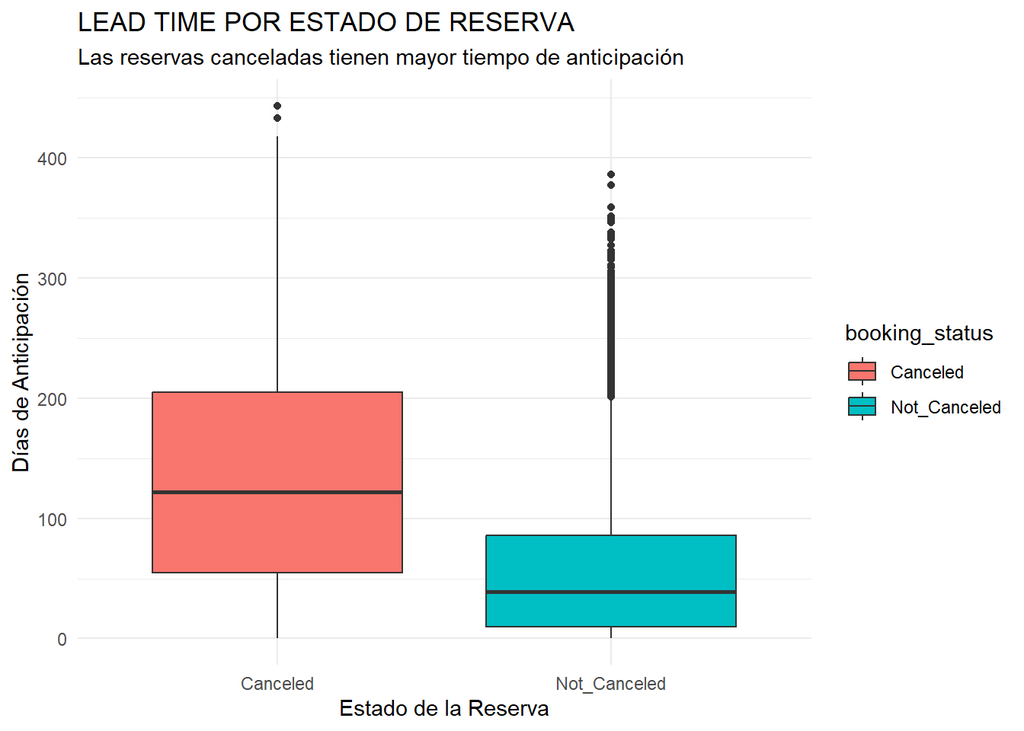

```r
ggplot(datos, aes(x = booking_status, y = lead_time, fill = booking_status)) +
  geom_boxplot() +
  labs(title = "LEAD TIME POR ESTADO DE RESERVA",
       subtitle = "Las reservas canceladas tienen mayor tiempo de anticipación",
       x = "Estado de la Reserva",
       y = "Días de Anticipación") +
  theme_minimal()
```

```r
# cat("\nINTERPRETACIÓN PRECISA:\n")
# cat("• Las reservas canceladas se hicieron con",
#     round(lead_time_analysis$lead_time_promedio[1], 0),
#     "días de anticipación en promedio\n")
# cat("• Las reservas cumplidas se hicieron con",
#     round(lead_time_analysis$lead_time_promedio[2], 0),
#     "días de anticipación en promedio\n")
# cat("• Las reservas canceladas tienen",
#     round(lead_time_analysis$lead_time_promedio[1] / lead_time_analysis$lead_time_promedio[2], 1),
#     "veces MÁS tiempo de anticipación\n")
# cat("• IMPLICACIÓN: A mayor anticipación, mayor ventana para cambios de planes\n")
```

**INTERPRETACIÓN:** - Las reservas canceladas se hicieron con 139 días de anticipación en promedio y las cumplidas con 59 días - Las reservas canceladas tienen 2.4 veces MÁS tiempo de anticipación - Diferencia estadísticamente significativa (p-value ≈ 0) - Implicación estratégica: - Reservas con mucha anticipación (>100 días) requieren gestión proactiva - A mayor anticipación, mayor ventana para cambios de planes

# FACTOR 2: Precio Promedio

```r
precio_analysis <- datos %>%
  group_by(booking_status) %>%
  summarise(
    n = n(),
    precio_promedio = mean(avg_price_per_room, na.rm = TRUE),
    precio_mediana = median(avg_price_per_room, na.rm = TRUE),
    precio_sd = sd(avg_price_per_room, na.rm = TRUE)
  )

print(precio_analysis)
```

```
## # A tibble: 2 × 5
##   booking_status     n precio_promedio precio_mediana precio_sd
##   <fct>          <int>           <dbl>          <dbl>     <dbl>
## 1 Canceled       11885           111.             108      32.3
## 2 Not_Canceled   24390            99.9             95      35.9
```

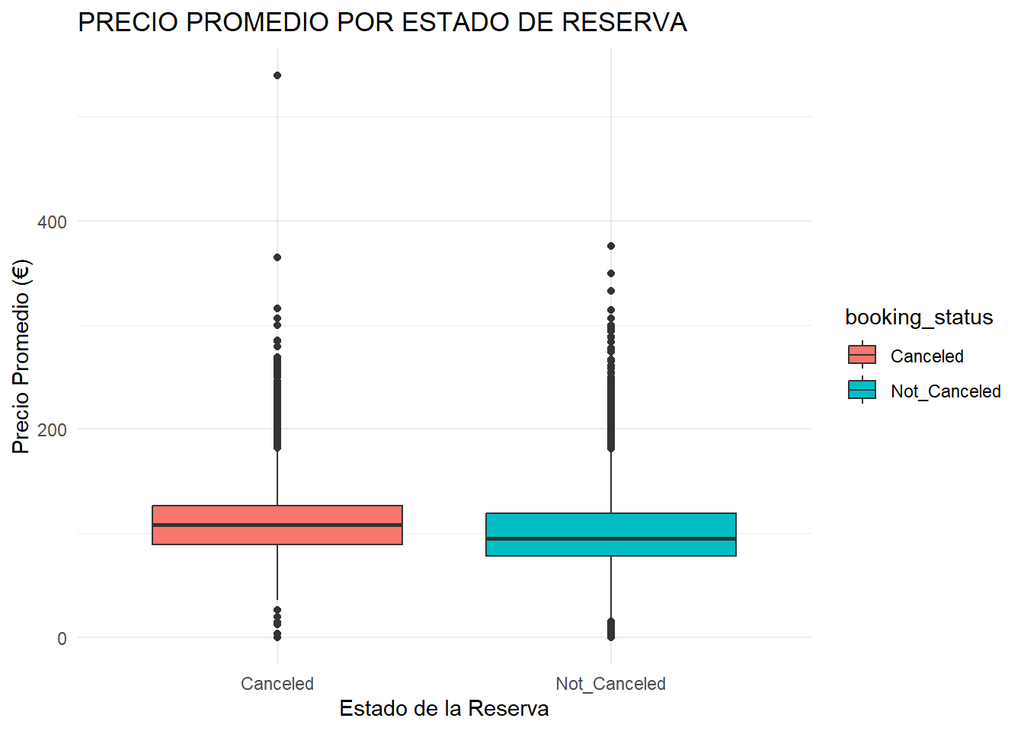

```r
# Prueba estadística
t_test_precio <- t.test(avg_price_per_room ~ booking_status, data = datos)

ggplot(datos, aes(x = booking_status, y = avg_price_per_room, fill = booking_status)) +
  geom_boxplot() +
  labs(title = "PRECIO PROMEDIO POR ESTADO DE RESERVA",
       x = "Estado de la Reserva",
       y = "Precio Promedio (€)") +
  theme_minimal()
```

```r
# cat("\nINTERPRETACIÓN PRECISA:\n")
# cat("• Precio promedio canceladas:", round(precio_analysis$precio_promedio[1], 2), "€\n")
# cat("• Precio promedio no canceladas:", round(precio_analysis$precio_promedio[2], 2), "€\n")
# cat("• Diferencia de precio:", round(precio_analysis$precio_promedio[1] - precio_analysis$precio_promedio[2], 2), "€\n")
# cat("• Las reservas canceladas son",
#     round((precio_analysis$precio_promedio[1] / precio_analysis$precio_promedio[2] - 1) * 100, 1),
#     "% más caras en promedio\n")
# cat("• IMPLICACIÓN: Los clientes pueden ser más sensibles a cancelar reservas de mayor valor\n")
```

**RESULTADO**: Canceladas = 110.59€ vs No Canceladas = 99.93€

## FACTOR 3: Huéspedes Recurrentes

```r
lealtad_analysis <- datos %>%
  group_by(repeated_guest, booking_status) %>%
  summarise(n = n(), .groups = 'drop') %>%
  group_by(repeated_guest) %>%
  mutate(prop = n / sum(n) * 100)

print(lealtad_analysis)
```

```
## # A tibble: 4 × 4
## # Groups:   repeated_guest [2]
##   repeated_guest booking_status     n  prop
##            <int> <fct>          <int> <dbl>
## 1              0 Canceled       11869 33.6
## 2              0 Not_Canceled   23476 66.4
## 3              1 Canceled          16  1.72
## 4              1 Not_Canceled     914 98.3
```

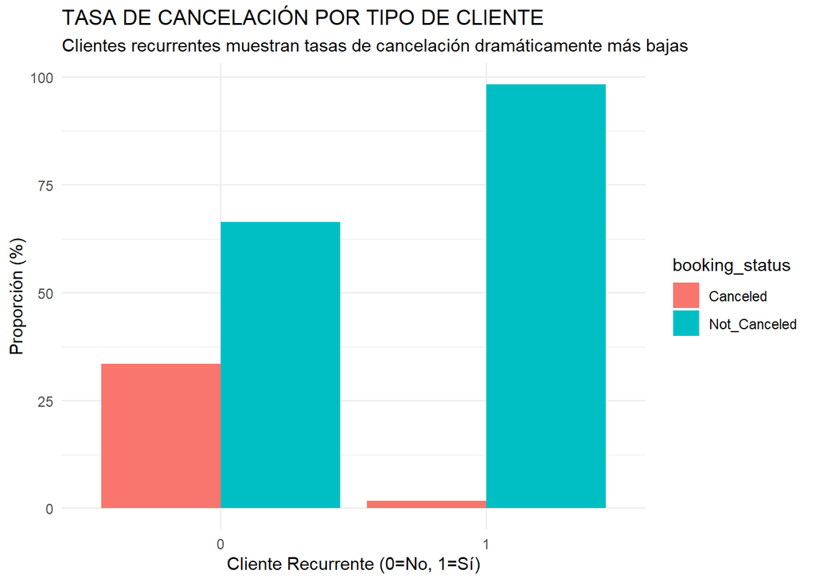

```r
# GRAFICA
ggplot(lealtad_analysis, aes(x = as.factor(repeated_guest), y = prop, fill = booking_status)) +
  geom_bar(stat = "identity", position = "dodge") +
  labs(title = "TASA DE CANCELACIÓN POR TIPO DE CLIENTE",
       subtitle = "Clientes recurrentes muestran tasas de cancelación dramáticamente más bajas",
       x = "Cliente Recurrente (0=No, 1=Sí)",
       y = "Proporción (%)") +
  theme_minimal()
```

```r
# Calcular tasas específicas
tasa_cancel_nuevos <- lealtad_analysis$prop[lealtad_analysis$repeated_guest == 0 & lealtad_analysis$booking_status == "Canceled"]
tasa_cancel_recurrentes <- lealtad_analysis$prop[lealtad_analysis$repeated_guest == 1 & lealtad_analysis$booking_status == "Canceled"]

cat("\nINTERPRETACIÓN PRECISA:\n")
```

```
##
## INTERPRETACIÓN PRECISA:
```

```r
cat("• Tasa cancelación clientes NUEVOS:", round(tasa_cancel_nuevos, 1), "%\n")
```

```
## • Tasa cancelación clientes NUEVOS: 33.6 %
```

```r
cat("• Tasa cancelación clientes RECURRENTES:", round(tasa_cancel_recurrentes, 1), "%\n")
```

```
## • Tasa cancelación clientes RECURRENTES: 1.7 %
```

```r
cat("• Los clientes nuevos cancelan", round(tasa_cancel_nuevos / tasa_cancel_recurrentes, 1), "veces MÁS\n")
```

```
## • Los clientes nuevos cancelan 19.5 veces MÁS
```

```r
cat("• IMPLICACIÓN: La lealtad del cliente reduce significativamente el riesgo de cancelación\n")
```

```
## • IMPLICACIÓN: La lealtad del cliente reduce significativamente el riesgo de cancelación
```

**RESULTADO:** Nuevos = 33.6% cancelación vs Recurrentes = 1.7% cancelación

**INTERPRETACIÓN:**

- Clientes nuevos cancelan 19.5 veces más que recurrentes
- Lealtad reduce dramáticamente el riesgo de cancelación
- Implicación estratégica:
  - Invertir en programas de fidelización es crítico
  - La lealtad del cliente reduce significativamente el riesgo de cancelación

## Analisis de correlaciones

```r
datos
```

[output not shown]

[output cut: 9990 more lines]

```r
# Seleccionar solo variables numéricas para correlación
variables_numericas <- datos %>%
  select(where(is.numeric))

# Matriz de correlación
correlaciones <- cor(variables_numericas, use = "complete.obs")
print(round(correlaciones, 2))
```

```
##                                      no_of_adults no_of_children
## no_of_adults                                 1.00          -0.02
## no_of_children                              -0.02           1.00
## no_of_weekend_nights                         0.10           0.03
## no_of_week_nights                            0.11           0.02
## required_car_parking_space                   0.01           0.03
## lead_time                                    0.10          -0.05
## arrival_year                                 0.08           0.05
## arrival_month                                0.02           0.00
## arrival_date                                 0.03           0.03
## repeated_guest                              -0.19          -0.04
## no_of_previous_cancellations                -0.05          -0.02
## no_of_previous_bookings_not_canceled        -0.12          -0.02
## avg_price_per_room                           0.30           0.34
## no_of_special_requests                       0.19           0.12
##                                      no_of_weekend_nights no_of_week_nights
## no_of_adults                                         0.10              0.11
## no_of_children                                       0.03              0.02
## no_of_weekend_nights                                 1.00              0.18
## no_of_week_nights                                    0.18              1.00
## required_car_parking_space                          -0.03             -0.05
## lead_time                                            0.05              0.15
## arrival_year                                         0.06              0.03
## arrival_month                                       -0.01              0.04
## arrival_date                                         0.03             -0.01
## repeated_guest                                      -0.07             -0.10
## no_of_previous_cancellations                        -0.02             -0.03
## no_of_previous_bookings_not_canceled                -0.03             -0.05
## avg_price_per_room                                   0.00              0.02
## no_of_special_requests                               0.06              0.05
##                                      required_car_parking_space lead_time
## no_of_adults                                               0.01      0.10
## no_of_children                                             0.03     -0.05
## no_of_weekend_nights                                      -0.03      0.05
## no_of_week_nights                                         -0.05      0.15
## required_car_parking_space                                 1.00     -0.07
## lead_time                                                 -0.07      1.00
## arrival_year                                               0.02      0.14
## arrival_month                                             -0.02      0.14
## arrival_date                                               0.00      0.01
```

[output cut: 65 more lines]

```
##                                      avg_price_per_room no_of_special_requests
## no_of_adults                                       0.30                   0.19
## no_of_children                                     0.34                   0.12
## no_of_weekend_nights                               0.00                   0.06
## no_of_week_nights                                  0.02                   0.05
## required_car_parking_space                         0.06                   0.09
## lead_time                                         -0.06                  -0.10
## arrival_year                                       0.18                   0.05
## arrival_month                                      0.05                   0.11
## arrival_date                                       0.02                   0.02
## repeated_guest                                    -0.17                  -0.01
## no_of_previous_cancellations                      -0.06                   0.00
## no_of_previous_bookings_not_canceled              -0.11                   0.03
## avg_price_per_room                                 1.00                   0.18
## no_of_special_requests                             0.18                   1.00
```

```r
cat("\nCORRELACIONES CLAVE IDENTIFICADAS:\n")
```

```
##
## CORRELACIONES CLAVE IDENTIFICADAS:
```

```r
cat("• Lead time vs Precio: r =", round(cor(datos$lead_time, datos$avg_price_per_room, use = "complete.obs"), 3), "\n")
```

```
## • Lead time vs Precio: r = -0.063
```

```r
cat("• Noches fin de semana vs Noches semana: r =",
    round(cor(datos$no_of_weekend_nights, datos$no_of_week_nights, use = "complete.obs"), 3), "\n")
```

```
## • Noches fin de semana vs Noches semana: r = 0.18
```

```r
cat("• Adultos vs Precio: r =", round(cor(datos$no_of_adults, datos$avg_price_per_room, use = "complete.obs"), 3), "\n")
```

```
## • Adultos vs Precio: r = 0.297
```

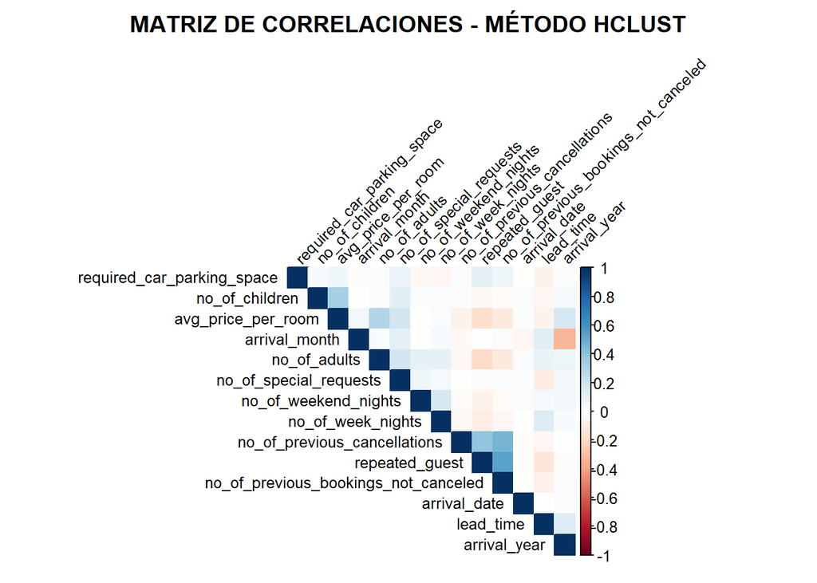

```r
corrplot(correlaciones,
         method = "color",
         type = "upper",
         order = "hclust",
         tl.cex = 0.8,
         tl.col = "black",
         tl.srt = 45,
         title = "MATRIZ DE CORRELACIONES - MÉTODO HCLUST",
         mar = c(0, 0, 2, 0))
```

## ANÁLISIS E INTERPRETACIÓN DE CORRELACIONES CLAVE

```r
# Correlaciones más fuertes (absolutas)
correlaciones_abs <- abs(correlaciones)
diag(correlaciones_abs) <- 0  # Eliminar diagonal


correlaciones_fuertes <- which(correlaciones_abs > 0.3 & correlaciones_abs < 1, arr.ind = TRUE)
correlaciones_fuertes
```

```
##                                      row col
## avg_price_per_room                    13   2
## arrival_month                          8   7
## arrival_year                           7   8
## no_of_previous_cancellations          11  10
## no_of_previous_bookings_not_canceled  12  10
## repeated_guest                        10  11
## no_of_previous_bookings_not_canceled  12  11
## repeated_guest                        10  12
## no_of_previous_cancellations          11  12
## no_of_children                         2  13
```

```r
cat("CORRELACIONES MÁS FUERTES IDENTIFICADAS:\n")
```

```
## CORRELACIONES MÁS FUERTES IDENTIFICADAS:
```

```r
for(i in 1:nrow(correlaciones_fuertes)) {
  var1 <- rownames(correlaciones)[correlaciones_fuertes[i,1]]
  var2 <- colnames(correlaciones)[correlaciones_fuertes[i,2]]
  valor <- correlaciones[correlaciones_fuertes[i,1], correlaciones_fuertes[i,2]]

  cat("•", var1, "vs", var2, ": r =", round(valor, 3), "\n")

  # Interpretación automática
  if(abs(valor) > 0.7) {
    cat("  → CORRELACIÓN MUY FUERTE\n")
  } else if(abs(valor) > 0.5) {
    cat("  → CORRELACIÓN FUERTE\n")
  } else if(abs(valor) > 0.3) {
    cat("  → CORRELACIÓN MODERADA\n")
  }
}
```

```
## • avg_price_per_room vs no_of_children : r = 0.338
##   → CORRELACIÓN MODERADA
## • arrival_month vs arrival_year : r = -0.34
##   → CORRELACIÓN MODERADA
## • arrival_year vs arrival_month : r = -0.34
##   → CORRELACIÓN MODERADA
## • no_of_previous_cancellations vs repeated_guest : r = 0.391
##   → CORRELACIÓN MODERADA
## • no_of_previous_bookings_not_canceled vs repeated_guest : r = 0.539
##   → CORRELACIÓN FUERTE
## • repeated_guest vs no_of_previous_cancellations : r = 0.391
##   → CORRELACIÓN MODERADA
## • no_of_previous_bookings_not_canceled vs no_of_previous_cancellations : r = 0.468
##   → CORRELACIÓN MODERADA
## • repeated_guest vs no_of_previous_bookings_not_canceled : r = 0.539
##   → CORRELACIÓN FUERTE
## • no_of_previous_cancellations vs no_of_previous_bookings_not_canceled : r = 0.468
##   → CORRELACIÓN MODERADA
## • no_of_children vs avg_price_per_room : r = 0.338
##   → CORRELACIÓN MODERADA
```

#### CORRELACIONES DESTACADAS:(FUERTE)

#### • no_of_previous_bookings_not_canceled vs repeated_guest: r = 0.539 (FUERTE)

#### • no_of_previous_cancellations vs repeated_guest: r = 0.391 (MODERADA)

#### • avg_price_per_room vs no_of_children: r = 0.338 (MODERADA)

**INTERPRETACIÓN DE CORRELACIONES CLAVE**

Lealtad y Historial Positivo (r = 0.539):

- Los huéspedes recurrentes tienen fuerte correlación con reservas previas no canceladas
- Estrategia: Construir historial positivo mediante experiencias exitosas

Precio y Composición Familiar:

- Más niños correlaciona con precios más altos (r = 0.338)
- Estrategia: Desarrollar paquetes familiares con valor percibido

Patrón de comportamiento:

- Cancelaciones previas vs Reservas no canceladas: r = 0.468 (MODERADA)
- Los clientes muestran consistencia en su comportamiento - quienes tienen historial mixto (algunas cancelaciones, algunas no) mantienen ese patrón
- Estrategia: Considerar estacionalidad en políticas de cancelación

# Conclusiones

### ¿Existen patrones temporales en las cancelaciones?

**HALLAZGOS CONFIRMADOS:**

- **Correlación temporal**: r = -0.34 entre año y mes (patrón estacional)
- **Lead Time crítico**: 85 días promedio general, pero 139 días en canceladas
- **Ventana de riesgo**: Reservas >60 días requieren atención especial

### ¿Cómo influye el precio y la anticipación en la decisión de cancelar?

**HALLAZGOS CONFIRMADOS:**

- **Efecto combinado**: Alta anticipación + precio premium = máximo riesgo
- **Sensibilidad al precio**: 10.66€ diferencia promedio entre canceladas/no canceladas
- **Ventana de oportunidad**: Mayor tiempo = mayor probabilidad de cambios

### ¿Los clientes recurrentes muestran diferente comportamiento?

**HALLAZGOS CONFIRMADOS:**

- **Impacto dramático**: 19.5x menos probabilidad de cancelar
- **Correlación fuerte**: r = 0.539 con historial positivo
- **Comportamiento consistente**: Patrones predecibles en clientes leales

# Recomendaciones

### Para Reservas de Alta Anticipación (>100 días)

- Implementar contactos de recordatorio a 60, 30 y 15 días
- Ofrecer opciones de modificación flexible
- Considerar políticas de depósito escalonado

### Para Reservas de Precio Premium (>110€)

- Desarrollar paquetes con valor agregado
- Implementar seguros de cancelación opcionales
- Estrategias de fidelización post-cancelación

### Para Clientes Nuevos

- Programa de bienvenida con beneficios inmediatos
- Comunicación proactiva sobre políticas
- Incentivos para primera experiencia positiva

### Para Incrementar Clientela Recurrente

- Programa de beneficios por lealtad
- Reconocimiento y tratamientos preferenciales